# Coordinating on-demand service supply and demand paper notes

Adam Spannbauer

2024-11-30

```r
library(tidyverse)
library(triangle)
library(patchwork)

plot_shaded_normal <- function(mean, sd, p = 0.5) {
  shade_up_to_x <- qnorm(p, mean = mean, sd = sd)

  data_normal <- data.frame(
    x = seq(mean - 4 * sd, mean + 4 * sd, length.out = 300)
  ) |>
    mutate(y = dnorm(x, mean = mean, sd = sd))

  shaded_data_normal <- data_normal |>
    filter(x <= shade_up_to_x)

  ggplot(data_normal, aes(x = x, y = y)) +
    geom_line() +
    geom_area(
      data = shaded_data_normal,
      aes(x = x, y = y),
      fill = "#ff8800",
      alpha = 0.3
    ) +
    geom_vline(xintercept = shade_up_to_x)
}

plot_shaded_triangle <- function(a, b, c = (a + b) / 2, p = 0.5) {
  shade_up_to_x <- triangle::qtriangle(p, a = a, b = b, c = c)

  data_tri <- data.frame(
    x = seq(a, b, length.out = 300)
  ) |>
    mutate(y = triangle::dtriangle(x, a = a, b = b, c = c))

  shaded_data_tri <- data_tri |>
    filter(x <= shade_up_to_x)

  ggplot(data_tri, aes(x = x, y = y)) +
    geom_line() +
    geom_area(
      data = shaded_data_tri,
      aes(x = x, y = y),
      fill = "#ff8800",
      alpha = 0.3
    ) +
    geom_vline(xintercept = shade_up_to_x)
}
```

Reading paper:

Bai, J., So, K. C., Tang, C. S., Chen, X., & Wang, H. (2019). Coordinating supply and demand on an on-demand service platform with impatient customers. Manufacturing & Service Operations Management, 21(3), 556-570. https://doi.org/10.1287/msom.2018.0707

# Notes

## General overview and goals

- Customers arrive randomly
- Each service consists of random amount of service units (e.g. travel distance)
  - Assumed any service can be rendered by any agent (maybe not true in reality where drivers cancel trips based on distance)
- Fixed price rate $p$ per service unit (e.g. dollars per kg)
- Fixed wage rate $w$ per service unit
- Payout ratio: $\frac{w}{p}$

No focus on surge pricing for ease of modeling and cites customer dissatisfaction if price jumps in short time span.

Assumed $p$ and $w$ are known to customers and agents in advance.

Goal of service platform is to set $p^*$ and $w^*$ to maximize average profit.

## Realized customer rate $\lambda$ and price rate $p$

### Setup

- Let $\lambda$ be the customer request rate with max amount of service in a time period is $\bar{\lambda}$
- Customer value per service unit is $v$ (heterogeneous with CDF $F(\cdot)$)
- For a customer with valuation $v$ and service request of $D$ units the surplus is $(v - p)D$
  - $D$ is assumed to be independent of customer-type $v$
  - expected value of service units will be modeled as $d = E(D)$
- Utility function of a customer can be modeled as $U(v) = (v - p)d - cW_q$
  - $v$ is value per service unit
  - $p$ is price per service unit
  - $d$ is expected value of service units
  - $c$ is cost of waiting
  - $W_q$ is expected wait time for service
- Realized customer request rate $\lambda$ is the percent of $\bar{\lambda}$ of customers who have $U(v) \ge 0$ for a given $p$
  - aka $\lambda = \text{Prob} \left\{ U(v) \ge 0 \right\} \cdot \bar{\lambda} \to \lambda = \text{Prob} \left\{ v \ge p + \frac{c}{d} W_q \right\} \cdot \bar{\lambda}$
  - steps
    - $(v-p)d-cW_q \ge 0$
    - $vd-pd-cW_q \ge 0$
    - $vd \ge pd-cW_q$
    - $v \ge p - \frac{c}{d}W_q$
- This probability is labeled $s$ (i.e. $s = \text{Prob} \left\{ v \ge p + \frac{c}{d} W_q \right\}$ and $\lambda = s \bar{\lambda}$) and represents the desired service rate. We can manipulate $p$ to decide what percentage of $\bar{\lambda}$ to target
- Since $v \sim F(\cdot)$ then the price rate satisfies $p = F^{-1} \left( 1 - \frac{\lambda}{\bar{\lambda}} \right) - \frac{c}{d} W_q$ (note this could be written $p = F^{-1} \left( 1 - s \right) - \frac{c}{d} W_q$ to show service rate more directly)
  - Steps
    - $\lambda = \text{Prob} \left\{ v \ge p + \frac{c}{d} W_q \right\} \cdot \bar{\lambda}$
    - $\lambda = \left[ 1 - F\left( p + \frac{c}{d} W_q \right) \right] \cdot \bar{\lambda}$
    - $\frac{\lambda}{\bar{\lambda}} = 1 - F\left( p + \frac{c}{d} W_q \right)$
    - $F\left( p + \frac{c}{d} W_q \right) = 1 - \frac{\lambda}{\bar{\lambda}}$
    - $p + \frac{c}{d} W_q = F^{-1}\left(1 - \frac{\lambda}{\bar{\lambda}}\right)$
    - $p = F^{-1}\left(1 - \frac{\lambda}{\bar{\lambda}}\right) - \frac{c}{d} W_q$ or $p = F^{-1}\left(1 - s\right) - \frac{c}{d} W_q$
  - Holding everything else constant
    - Price rate decreases as wait time ( $W_q$ ) increases
    - Price rate decreases as unit wait cost ( $c$ ) increases
    - Price rate increases as number of service units ( $d$ ) increases

### Final results

For a given service rate ( $s$ ), wait time ( $W_q$ ), expected service units ( $d$ ), cost of wait per unit time ( $c$ ), & distribution of $v$ ( $v \sim F(\cdot)$ ) we can prescribe a price to obtain $s$:

$$p = F^{-1}\left(1 - s\right) - \frac{c}{d} W_q$$

Customers assign different values ( $v$ ) for the service per unit. $v \sim F( \cdot )$. Exploring normal and triangle distributions for ease. Likely a right skewed distribution in practice, but perhaps those out in the tail of the a heavy right skewed dist are out of the customer base for these on demand services.

```r
# Price rate as a function of service level
price_rate <- function(s, c, d, Wq, Finv) {
  Finv(1 - s) - (c / d) * Wq
}
```

#### How price varies with individual params

Holding all other factors constant and just manipulating the input shown on x axis.

Service level $s$ is not plotted, but as desired service level is increases, the prescribed price decreases (make cheaper to get more of market; make more expensive to out price parts of market).

These relationships are the similar in behavior regardless of choice of value distribution family ( $F(\cdot)$ ).

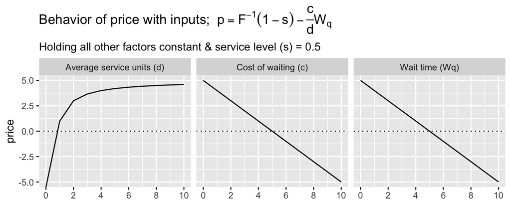

```r
ex_range <- 0:10

s <- 0.5
c <- 2
d <- 2
Wq <- 2

# value dist (normal) params
mu <- 5
sd <- 1
Finv <- \(p) qnorm(p = p, mean = mu, sd = sd)

ex_c <- price_rate(s, ex_range, d, Wq, Finv)
ex_d <- price_rate(s, c, ex_range, Wq, Finv)
ex_Wq <- price_rate(s, c, d, ex_range, Finv)

func_behavior_df <- data.frame(
  ex_range = ex_range,
  c = ex_c,
  d = ex_d,
  Wq = ex_Wq
)

func_behavior_df |>
  pivot_longer(-ex_range) |>
  mutate(name = ifelse(name == "c", "Cost of waiting (c)", name)) |>
  mutate(name = ifelse(name == "d", "Average service units (d)", name)) |>
  mutate(name = ifelse(name == "Wq", "Wait time (Wq)", name)) |>
  ggplot(aes(x = ex_range, y = value)) +
  geom_line() +
  geom_hline(yintercept = 0, linetype = "dotted") +
  facet_wrap(~name) +
  scale_x_continuous(breaks = seq(0, 10, 2)) +
  labs(
    y = "price", x = "",
    title = bquote("Behavior of price with inputs; " ~
      p == F^
        {
          -1
        } * (1 - s) - frac(c, d) * W[q]),
    subtitle = "Holding all other factors constant & service level (s) = 0.5"
  )
```

#### Triangle distribution of value $v \sim F_{triangle}(\cdot)$

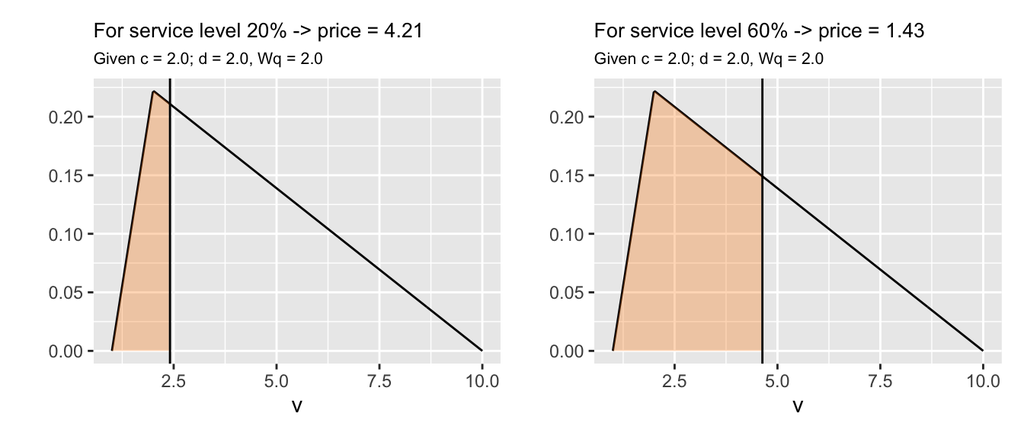

```r
c <- 2
d <- 2
Wq <- 2

# value dist (triangle) params
a <- 1
b <- 10
c <- 2
Finv <- \(p) qtriangle(p = p, a = a, b = b, c = c)

s <- 0.2
p1 <- plot_shaded_triangle(a = a, b = b, c = c, p = s) +
  labs(
    title = sprintf(
      "For service level %.0f%% -> price = %.2f ",
      s * 100, price_rate(s, c, d, Wq, Finv)
    ),
    subtitle = sprintf("Given c = %.1f; d = %.1f, Wq = %.1f", c, d, Wq),
    x = "v",
    y = ""
  ) +
  theme(
    plot.title = element_text(size = 10),
    plot.subtitle = element_text(size = 8)
  )


s <- 0.6
p2 <- plot_shaded_triangle(a = a, b = b, c = c, p = s) +
  labs(
    title = sprintf(
      "For service level %.0f%% -> price = %.2f ",
      s * 100, price_rate(s, c, d, Wq, Finv)
    ),
    subtitle = sprintf("Given c = %.1f; d = %.1f, Wq = %.1f", c, d, Wq),
    x = "v",
    y = ""
  ) +
  theme(
    plot.title = element_text(size = 10),
    plot.subtitle = element_text(size = 8)
  )


p1 + p2
```

#### Normal distribution of value $v \sim F_{normal}(\cdot)$

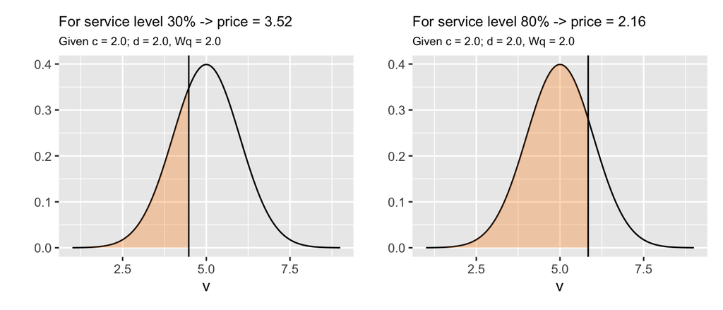

```r
c <- 2
d <- 2
Wq <- 2

# value dist (normal) params
mu <- 5
sd <- 1
Finv <- \(p) qnorm(p = p, mean = mu, sd = sd)

s <- 0.3
p1 <- plot_shaded_normal(mean = mu, sd = sd, p = s) +
  labs(
    title = sprintf(
      "For service level %.0f%% -> price = %.2f ",
      s * 100, price_rate(s, c, d, Wq, Finv)
    ),
    subtitle = sprintf("Given c = %.1f; d = %.1f, Wq = %.1f", c, d, Wq),
    x = "v",
    y = ""
  ) +
  theme(
    plot.title = element_text(size = 10), # Shrink title font size
    plot.subtitle = element_text(size = 8) # Shrink subtitle font size
  )

s <- 0.8
p2 <- plot_shaded_normal(mean = mu, sd = sd, p = s) +
  labs(
    title = sprintf(
      "For service level %.0f%% -> price = %.2f ",
      s * 100, price_rate(s, c, d, Wq, Finv)
    ),
    subtitle = sprintf("Given c = %.1f; d = %.1f, Wq = %.1f", c, d, Wq),
    x = "v",
    y = ""
  ) +
  theme(
    plot.title = element_text(size = 10),
    plot.subtitle = element_text(size = 8)
  )

p1 + p2
```

## Realized providers $k$ and wage rate $w$

- $K$ - maximum number of potential providers
- $k$ - realized number of providers for a given price $p$ and wage rate $w$ (wage as a percentage - $\alpha$ - of $p$)
  - $k \le K$
- $\mu$ - average service speed; so $\frac{\mu}{d}$ is service rate (i.e. average number of customers served per hour; $d$ is average service units requested)
- Given realized customers ( $\lambda$ ) and realized providers ( $k$ ), the utilization is $\frac{\lambda}{k \cdot (\mu / d)}$
  - Similar to typical queueing $\rho = \frac{\lambda}{\mu}$, but incorporating $k$ providers and $d$ average service units
- Wage per unit time of provider is $w$

# Slides

[figure not shown]